# Predicting activity using fitness tracker data

Streckereck

Tuesday, June 16, 2015

**Introduction** The purpose of this analysis is to predict the manner (quality) of physical activity using data collected using personal fitness tracker devises such as Jawbone Up, Nike FuelBand, and Fitbit. The goal is to predict the quality an excersize based on accelerometer measurments. This type of prediction could be useful for monitoring physical performance and providing feedback for physical activies and exersize.

**Instructions** You should create a report describing how you built your model, how you used cross validation, what you think the expected out of sample error is, and why you made the choices you did. You will also use your prediction model to predict 20 different test cases.

**Methods**

1. The data were downloaded.
2. The data were summarized and plotted to explore different relationships and strategies for analyses.
3. Machine learning algorithms were applied to the training data and compared based on accuracy of classification and other practical considerations
   - The data were split 60 / 40% training and testing to cross validate the model
   - The test data were used only once on the final model
4. The highest performing machine learning approach was tested using the test cases

*1) Download and clean the data*

```r
setwd ("C:/working/coursera/")

library (caret)
```

```r
# dl data
# download.file("https://d396qusza40orc.cloudfront.net/predmachlearn/pml-training.csv",
#                "pml.csv")
pml <- read.csv("pml.csv")

pml$classe <- as.factor(pml$classe)

# 60 / 40% split for training and validation
set.seed(1224)
train <- createDataPartition(y=pml$classe,
                                         p = 0.6,
                                         list=F)

training <- pml[train,]
testing <- pml[-train,]


#test cases
# download.file("https://d396qusza40orc.cloudfront.net/predmachlearn/pml-testing.csv",
#                "pml-testcases.csv")
pml_testcases <- read.csv("pml-testcases.csv")
```

*2) Summarize and plot the data*

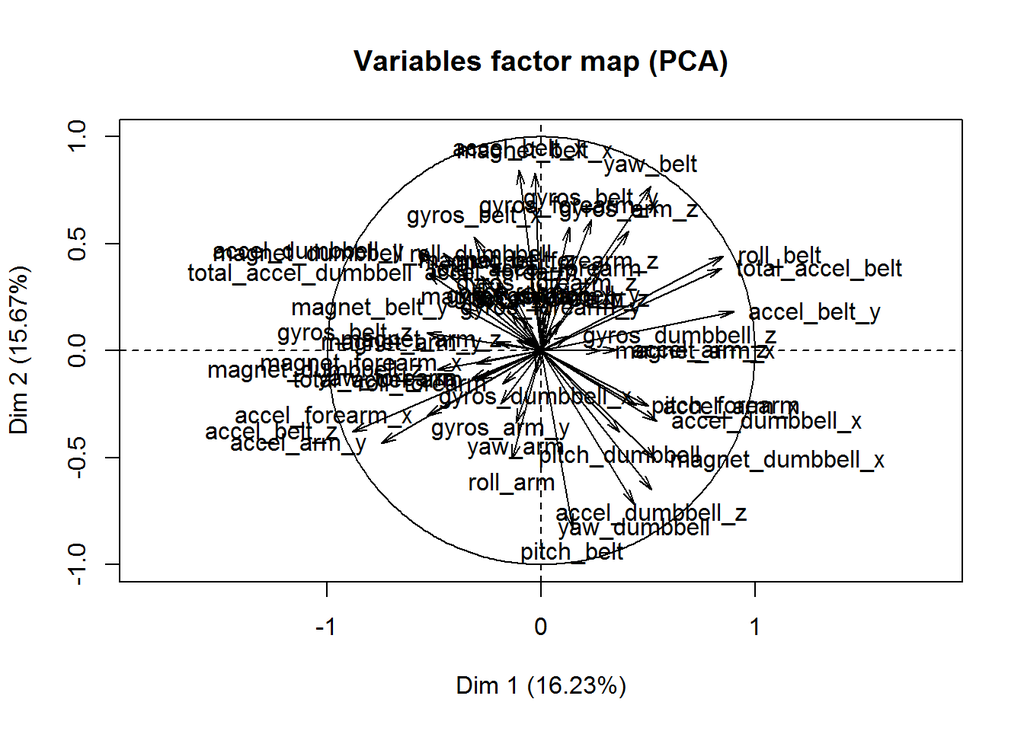

```r
# first check for zero variance
nzv <- nearZeroVar(training, saveMetrics=T) # check for zero variance

# many of the variables have zero variance, and these can be safely ignored
nzvVar <- which(nzv$nzv == T)

pml_training_vars <- training[,-nzvVar]

# some of the columns have a lot of NA's... let's look at those:
NAs <- apply(pml_training_vars, 2, function(column){
        sum(is.na(column))
})

# These can be removed
pml_training_vars<- pml_training_vars[,which(as.integer(NAs)==0)]

# look at the highly correlated variables

qualVars <- c(1:6,59) # metadata variables, not used in analysis
M <- abs(cor(pml_training_vars[,-qualVars]))
diag(M)<-0
highlyCorrelated <- which(M>0.75, arr.ind=T)

# there are a lot of multicollinear variables here. One approach might be to perform
# a principal components analysis as a variable reduction pre-processing step,
# if the anlalysis is sensative to colinearity

# there are too many variables to visualize using a pairs plot, and these might
# miss relationships that occur with three or more variables.
# instead, we can use PCA as a way to display multiple dimensions in an optimized
# way in a reduced set of dimensions (just to get an idea what is going on in the data)
# for example, we can display a bi-plot with the correlations between the variables
# and the factor loadings in the PCA (Venerables and Ripley p. 335, Husson and Pages)

library(FactoMineR)
pca <- pml_training_vars[,c(59,7:58)]
response <- c(2:53)
res.pca<-PCA(pca, response, quali.sup=1, graph = F)
plot(res.pca, axes=c(1:2), choix="var")
```

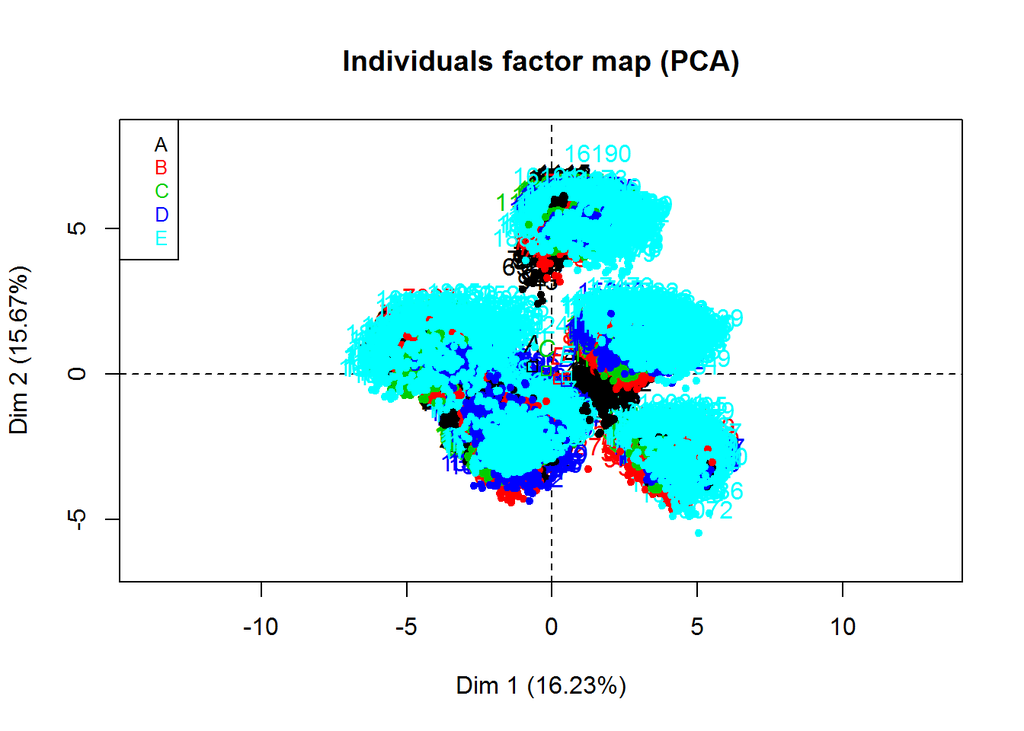

```r
#plot(res.pca, axes=c(3:4), choix="var")
#dimdesc(res.pca)

plot(res.pca, axes=c(1:2), choix="ind", habillage=1)
```